# Chapter 10 Seaborn _Exercise2 - diamonds - sol

```python
import pandas as pd
import seaborn as sb
import matplotlib.pyplot as plt
```

Load the diamonds dataset

```python
#1
df = sb.load_dataset('diamonds')
```

use head,info and describe

```python
#2
df.info()
```

```
<class 'pandas.core.frame.DataFrame'>
RangeIndex: 53940 entries, 0 to 53939
Data columns (total 10 columns):
 #   Column   Non-Null Count  Dtype
---  ------   --------------  -----
 0   carat    53940 non-null  float64
 1   cut      53940 non-null  category
 2   color    53940 non-null  category
 3   clarity  53940 non-null  category
 4   depth    53940 non-null  float64
 5   table    53940 non-null  float64
 6   price    53940 non-null  int64
 7   x        53940 non-null  float64
 8   y        53940 non-null  float64
 9   z        53940 non-null  float64
dtypes: category(3), float64(6), int64(1)
memory usage: 3.0 MB
```

```python
#2
df.head()
```

|  | carat | cut | color | clarity | depth | table | price | x | y | z |
| --- | --- | --- | --- | --- | --- | --- | --- | --- | --- | --- |
| 0 | 0.23 | Ideal | E | SI2 | 61.5 | 55.0 | 326 | 3.95 | 3.98 | 2.43 |
| 1 | 0.21 | Premium | E | SI1 | 59.8 | 61.0 | 326 | 3.89 | 3.84 | 2.31 |
| 2 | 0.23 | Good | E | VS1 | 56.9 | 65.0 | 327 | 4.05 | 4.07 | 2.31 |
| 3 | 0.29 | Premium | I | VS2 | 62.4 | 58.0 | 334 | 4.20 | 4.23 | 2.63 |
| 4 | 0.31 | Good | J | SI2 | 63.3 | 58.0 | 335 | 4.34 | 4.35 | 2.75 |

```python
#2
df.describe()
```

|  | carat | depth | table | price | x | y | z |
| --- | --- | --- | --- | --- | --- | --- | --- |
| count | 53940.000000 | 53940.000000 | 53940.000000 | 53940.000000 | 53940.000000 | 53940.000000 | 53940.000000 |
| mean | 0.797940 | 61.749405 | 57.457184 | 3932.799722 | 5.731157 | 5.734526 | 3.538734 |
| std | 0.474011 | 1.432621 | 2.234491 | 3989.439738 | 1.121761 | 1.142135 | 0.705699 |
| min | 0.200000 | 43.000000 | 43.000000 | 326.000000 | 0.000000 | 0.000000 | 0.000000 |
| 25% | 0.400000 | 61.000000 | 56.000000 | 950.000000 | 4.710000 | 4.720000 | 2.910000 |
| 50% | 0.700000 | 61.800000 | 57.000000 | 2401.000000 | 5.700000 | 5.710000 | 3.530000 |
| 75% | 1.040000 | 62.500000 | 59.000000 | 5324.250000 | 6.540000 | 6.540000 | 4.040000 |
| max | 5.010000 | 79.000000 | 95.000000 | 18823.000000 | 10.740000 | 58.900000 | 31.800000 |

How many diamonds per color?

```python
#3
df.color.value_counts()
```

```
G    11292
E     9797
F     9542
H     8304
D     6775
I     5422
J     2808
Name: color, dtype: int64
```

How many diamonds per cut?

```python
#4
df.cut.value_counts()
```

```
Ideal        21551
Premium      13791
Very Good    12082
Good          4906
Fair          1610
Name: cut, dtype: int64
```

How many diamonds per clarity?

```python
#5
df.clarity.value_counts()
```

```
SI1     13065
VS2     12258
SI2      9194
VS1      8171
VVS2     5066
VVS1     3655
IF       1790
I1        741
Name: clarity, dtype: int64
```

What is the average price per cut?

```python
#6
df.groupby(['cut']).mean(numeric_only=True)
```

| cut | carat | depth | table | price | x | y | z |
| --- | --- | --- | --- | --- | --- | --- | --- |
| Ideal | 0.702837 | 61.709401 | 55.951668 | 3457.541970 | 5.507451 | 5.520080 | 3.401448 |
| Premium | 0.891955 | 61.264673 | 58.746095 | 4584.257704 | 5.973887 | 5.944879 | 3.647124 |
| Very Good | 0.806381 | 61.818275 | 57.956150 | 3981.759891 | 5.740696 | 5.770026 | 3.559801 |
| Good | 0.849185 | 62.365879 | 58.694639 | 3928.864452 | 5.838785 | 5.850744 | 3.639507 |
| Fair | 1.046137 | 64.041677 | 59.053789 | 4358.757764 | 6.246894 | 6.182652 | 3.982770 |

Show all diamonds with price less than 1000$

```python
#7
df.query("price < 1000")
```

|  | carat | cut | color | clarity | depth | table | price | x | y | z |
| --- | --- | --- | --- | --- | --- | --- | --- | --- | --- | --- |
| 0 | 0.23 | Ideal | E | SI2 | 61.5 | 55.0 | 326 | 3.95 | 3.98 | 2.43 |
| 1 | 0.21 | Premium | E | SI1 | 59.8 | 61.0 | 326 | 3.89 | 3.84 | 2.31 |
| 2 | 0.23 | Good | E | VS1 | 56.9 | 65.0 | 327 | 4.05 | 4.07 | 2.31 |
| 3 | 0.29 | Premium | I | VS2 | 62.4 | 58.0 | 334 | 4.20 | 4.23 | 2.63 |
| 4 | 0.31 | Good | J | SI2 | 63.3 | 58.0 | 335 | 4.34 | 4.35 | 2.75 |
| ... | ... | ... | ... | ... | ... | ... | ... | ... | ... | ... |
| 53635 | 0.30 | Ideal | I | VVS1 | 62.1 | 56.0 | 552 | 4.30 | 4.33 | 2.68 |
| 53636 | 0.30 | Ideal | D | SI1 | 61.6 | 57.0 | 552 | 4.28 | 4.32 | 2.65 |
| 53637 | 0.30 | Very Good | D | SI1 | 62.5 | 57.0 | 552 | 4.26 | 4.28 | 2.67 |
| 53638 | 0.30 | Ideal | D | SI1 | 61.0 | 57.0 | 552 | 4.29 | 4.33 | 2.63 |
| 53639 | 0.30 | Ideal | D | SI1 | 61.0 | 56.0 | 552 | 4.35 | 4.37 | 2.66 |

14499 rows × 10 columns

```python
sb.set_theme()
```

Show price distribution (using seaborn displot)

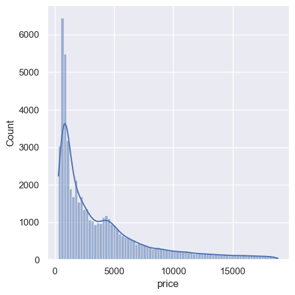

```python
#8
sb.displot(df.price,kde=True)
```

using countplot show how many diamonds per cut

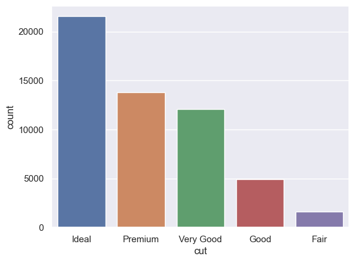

```python
#9
sb.countplot(data=df,x='cut')
```

using countplot show how many diamonds per color in y axis

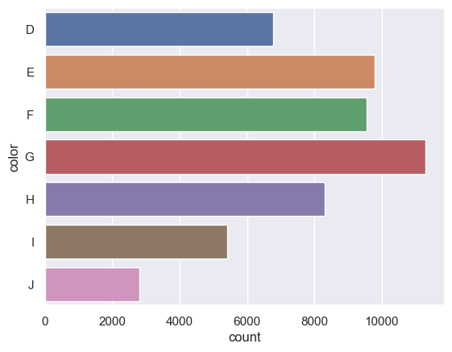

```python
#10
sb.countplot(data= df, y="color" )
```

using countplot show how many diamonds per cut and color (using hue)

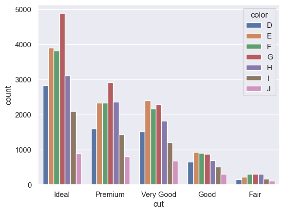

```python
#11
sb.countplot(data=df,x='cut',hue='color')
```

display dataset correlation

```python
#12
df.corr(numeric_only=True)
```

|  | carat | depth | table | price | x | y | z |
| --- | --- | --- | --- | --- | --- | --- | --- |
| carat | 1.000000 | 0.028224 | 0.181618 | 0.921591 | 0.975094 | 0.951722 | 0.953387 |
| depth | 0.028224 | 1.000000 | -0.295779 | -0.010647 | -0.025289 | -0.029341 | 0.094924 |
| table | 0.181618 | -0.295779 | 1.000000 | 0.127134 | 0.195344 | 0.183760 | 0.150929 |
| price | 0.921591 | -0.010647 | 0.127134 | 1.000000 | 0.884435 | 0.865421 | 0.861249 |
| x | 0.975094 | -0.025289 | 0.195344 | 0.884435 | 1.000000 | 0.974701 | 0.970772 |
| y | 0.951722 | -0.029341 | 0.183760 | 0.865421 | 0.974701 | 1.000000 | 0.952006 |
| z | 0.953387 | 0.094924 | 0.150929 | 0.861249 | 0.970772 | 0.952006 | 1.000000 |

create heatmap from the dataset correlation

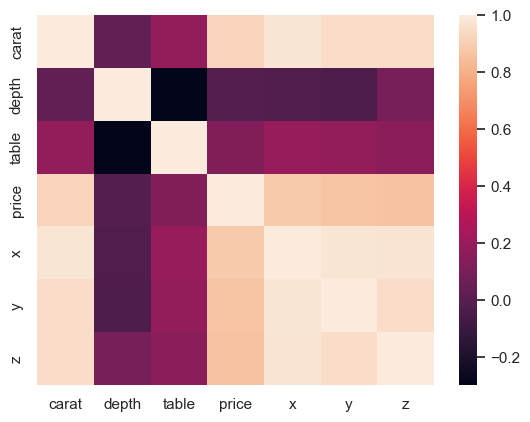

```python
#13
sb.heatmap(df.corr(numeric_only=True))
```

Create a pair plot

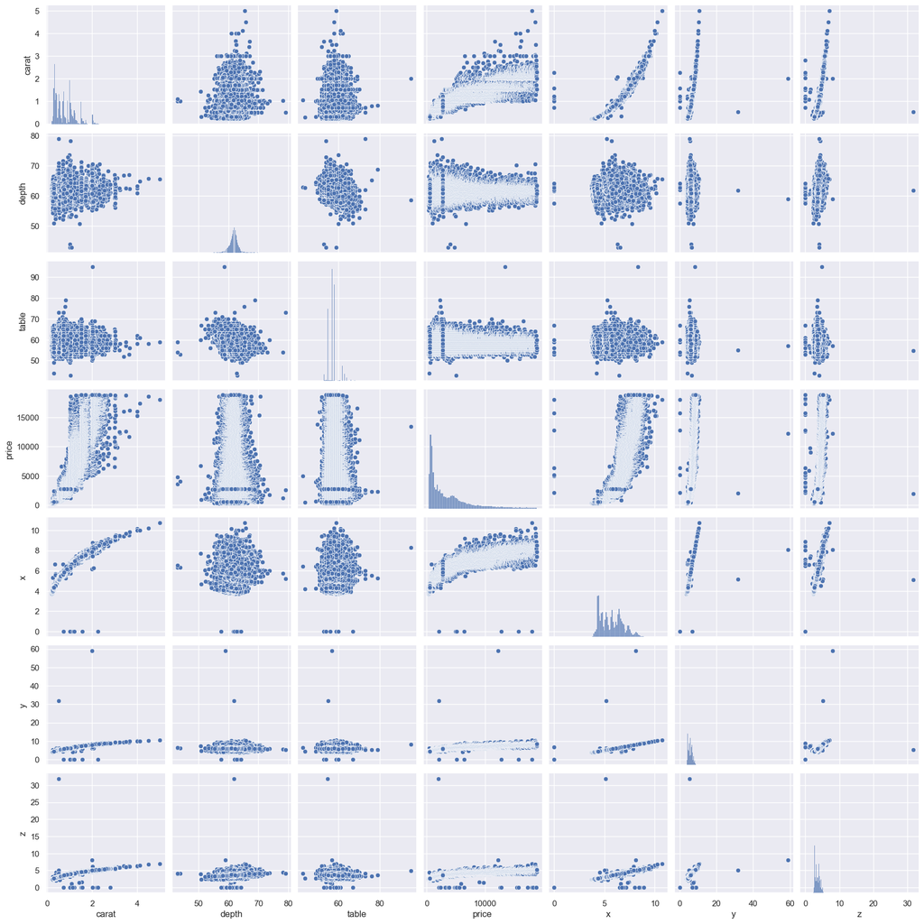

```python
#14
sb.pairplot(df)
```

Find all the diamonds with more than 10 percent difference between x and y

```python
#15
df.query("x/y < 0.9 or x/y > 1.1")
```

|  | carat | cut | color | clarity | depth | table | price | x | y | z |
| --- | --- | --- | --- | --- | --- | --- | --- | --- | --- | --- |
| 2274 | 1.22 | Premium | J | SI2 | 62.6 | 59.0 | 3156 | 6.79 | 4.24 | 3.76 |
| 11182 | 1.07 | Ideal | F | SI2 | 61.6 | 56.0 | 4954 | 0.00 | 6.62 | 0.00 |
| 14029 | 1.22 | Ideal | H | SI2 | 61.1 | 57.0 | 5703 | 6.90 | 5.92 | 4.22 |
| 14344 | 1.22 | Ideal | H | SI2 | 61.1 | 57.0 | 5807 | 6.90 | 5.92 | 4.22 |
| 15235 | 1.12 | Premium | H | VS1 | 61.6 | 58.0 | 6115 | 6.64 | 4.11 | 3.70 |
| 17826 | 1.51 | Fair | H | VS2 | 65.6 | 56.0 | 7188 | 7.08 | 4.70 | 4.00 |
| 19502 | 1.57 | Fair | H | VS1 | 67.3 | 66.0 | 8133 | 7.85 | 5.75 | 3.87 |
| 24067 | 2.00 | Premium | H | SI2 | 58.9 | 57.0 | 12210 | 8.09 | 58.90 | 8.06 |
| 27646 | 2.01 | Fair | G | SI1 | 70.6 | 64.0 | 18574 | 7.43 | 6.64 | 4.69 |
| 33102 | 0.34 | Good | E | VS2 | 57.0 | 61.0 | 816 | 6.65 | 4.61 | 2.64 |
| 34282 | 0.39 | Premium | H | SI2 | 61.2 | 58.0 | 468 | 4.51 | 6.02 | 4.44 |
| 48832 | 0.53 | Ideal | F | VVS2 | 62.7 | 56.0 | 2030 | 5.16 | 6.20 | 3.25 |
| 49189 | 0.51 | Ideal | E | VS1 | 61.8 | 55.0 | 2075 | 5.15 | 31.80 | 5.12 |
| 49875 | 0.70 | Premium | H | SI1 | 62.0 | 61.0 | 2176 | 6.65 | 5.69 | 3.46 |
| 49915 | 0.70 | Premium | F | SI1 | 62.6 | 55.0 | 2184 | 5.65 | 4.50 | 3.00 |
| 51625 | 0.70 | Premium | E | SI1 | 61.2 | 62.0 | 2396 | 6.65 | 5.73 | 3.48 |

use scatterplot to find correlation between x and y

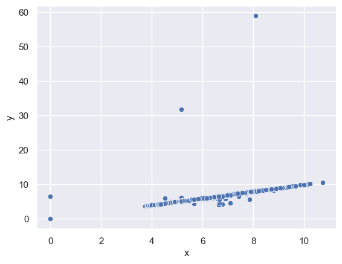

```python
#16
sb.scatterplot(data=df ,x="x" , y="y")
```

Find all the diamonds with z > x

```python
#17
df.query("z>x")
```

|  | carat | cut | color | clarity | depth | table | price | x | y | z |
| --- | --- | --- | --- | --- | --- | --- | --- | --- | --- | --- |
| 48410 | 0.51 | Very Good | E | VS1 | 61.8 | 54.7 | 1970 | 5.12 | 5.15 | 31.80 |
| 49905 | 0.50 | Very Good | G | VVS1 | 63.7 | 58.0 | 2180 | 5.01 | 5.04 | 5.06 |

# Data preparing

delete all the diamonds with more than 10 percent difference between x and y

```python
#18
df.drop(df.query("x/y < 0.9 or x/y > 1.1").index , inplace=True)
```

delete all the diamonds with z>x

```python
#19
df.drop(df.query("z>x").index , inplace=True)
```

Create a new column 'xy' with the mean value of x and y

```python
#20
df['xy']=(df.x + df.y)/2
```

```python
#21
df.head()
```

|  | carat | cut | color | clarity | depth | table | price | x | y | z | xy |
| --- | --- | --- | --- | --- | --- | --- | --- | --- | --- | --- | --- |
| 0 | 0.23 | Ideal | E | SI2 | 61.5 | 55.0 | 326 | 3.95 | 3.98 | 2.43 | 3.965 |
| 1 | 0.21 | Premium | E | SI1 | 59.8 | 61.0 | 326 | 3.89 | 3.84 | 2.31 | 3.865 |
| 2 | 0.23 | Good | E | VS1 | 56.9 | 65.0 | 327 | 4.05 | 4.07 | 2.31 | 4.060 |
| 3 | 0.29 | Premium | I | VS2 | 62.4 | 58.0 | 334 | 4.20 | 4.23 | 2.63 | 4.215 |
| 4 | 0.31 | Good | J | SI2 | 63.3 | 58.0 | 335 | 4.34 | 4.35 | 2.75 | 4.345 |

delete columns x,y

```python
#22
df.drop(['x','y'],axis=1,inplace=True)
```

```python
#23
df.head()
```

|  | carat | cut | color | clarity | depth | table | price | z | xy |
| --- | --- | --- | --- | --- | --- | --- | --- | --- | --- |
| 0 | 0.23 | Ideal | E | SI2 | 61.5 | 55.0 | 326 | 2.43 | 3.965 |
| 1 | 0.21 | Premium | E | SI1 | 59.8 | 61.0 | 326 | 2.31 | 3.865 |
| 2 | 0.23 | Good | E | VS1 | 56.9 | 65.0 | 327 | 2.31 | 4.060 |
| 3 | 0.29 | Premium | I | VS2 | 62.4 | 58.0 | 334 | 2.63 | 4.215 |
| 4 | 0.31 | Good | J | SI2 | 63.3 | 58.0 | 335 | 2.75 | 4.345 |

```python
#24
df.groupby(['color']).mean(numeric_only=True)
```

| color | carat | depth | table | price | z | xy |
| --- | --- | --- | --- | --- | --- | --- |
| D | 0.657795 | 61.698125 | 57.404590 | 3169.954096 | 3.342827 | 5.419089 |
| E | 0.657925 | 61.662586 | 57.490922 | 3077.268151 | 3.337659 | 5.413899 |
| F | 0.736529 | 61.694391 | 57.434092 | 3725.096761 | 3.464880 | 5.617501 |
| G | 0.771105 | 61.756156 | 57.287972 | 3998.005846 | 3.504779 | 5.678806 |
| H | 0.911506 | 61.836355 | 57.516622 | 4485.233968 | 3.695193 | 5.980706 |
| I | 1.026927 | 61.846385 | 57.577278 | 5091.874954 | 3.845411 | 6.222778 |
| J | 1.162116 | 61.886961 | 57.811970 | 5324.590310 | 4.033349 | 6.519079 |

Convert the color feature to int value

```python
#25
df.color.replace({'E':1 , 'D':2 , 'F':3 , 'G':4 , 'H':5 , 'I':6 , 'J':7},inplace=True)
```

```python
#26
df.head()
```

|  | carat | cut | color | clarity | depth | table | price | z | xy |
| --- | --- | --- | --- | --- | --- | --- | --- | --- | --- |
| 0 | 0.23 | Ideal | 1 | SI2 | 61.5 | 55.0 | 326 | 2.43 | 3.965 |
| 1 | 0.21 | Premium | 1 | SI1 | 59.8 | 61.0 | 326 | 2.31 | 3.865 |
| 2 | 0.23 | Good | 1 | VS1 | 56.9 | 65.0 | 327 | 2.31 | 4.060 |
| 3 | 0.29 | Premium | 6 | VS2 | 62.4 | 58.0 | 334 | 2.63 | 4.215 |
| 4 | 0.31 | Good | 7 | SI2 | 63.3 | 58.0 | 335 | 2.75 | 4.345 |

delete the columns cut and clarity

```python
#27
df.drop(['cut','clarity'],axis=1,inplace=True)
```

```python
#28
df.head()
```

|  | carat | color | depth | table | price | z | xy |
| --- | --- | --- | --- | --- | --- | --- | --- |
| 0 | 0.23 | 1 | 61.5 | 55.0 | 326 | 2.43 | 3.965 |
| 1 | 0.21 | 1 | 59.8 | 61.0 | 326 | 2.31 | 3.865 |
| 2 | 0.23 | 1 | 56.9 | 65.0 | 327 | 2.31 | 4.060 |
| 3 | 0.29 | 6 | 62.4 | 58.0 | 334 | 2.63 | 4.215 |
| 4 | 0.31 | 7 | 63.3 | 58.0 | 335 | 2.75 | 4.345 |